# roahd Package: Robust Analysis of High Dimensional Data

Francesca Ieva

MOX - Department of Mathematics, Politecnico di Milano

Anna Maria Paganoni

MOX - Department of Mathematics, Politecnico di Milano

Juan Romo

Department of Statistics, Universidad Carlos III de Madrid

Nicholas Tarabelloni

MOX - Department of Mathematics, Politecnico di Milano

2019-08-17

Abstract

The focus of this paper is on the open-source R package *roahd* (**RO**bust **A**nalysis of **H**igh dimensional **D**ata), see (Nicholas Tarabelloni et al. 2017). *roahd* has been developed to gather recently proposed statistical methods that deal with the robust inferential analysis of univariate and multivariate functional data. In particular, efficient methods for outlier detection and related graphical tools, methods to represent and simulate functional data, as well as inferential tools for testing differences and dependency among families of curves will be discussed, and the associated functions of the package will be described in details.

# Introduction

Functional Data Analysis (FDA) has seen an impressive growth in the statistical research due to the more and more frequent production of complex data in many different research contexts (i.e., healthcare, environmental, engineering, etc.). According to the FDA model, data can be seen as measurements of a certain quantity (or a set of quantities) along a given, independent and continuous indexing variable (such as time or space). Observations are then treated as random functions and can be viewed as trajectories of stochastic processes defined on a given infinite dimensional functional space. In this context ‘high dimensional data’ is meant in this sense: a high number of covariates/predictors (e.g., evaluations of a signal on a given grid) for a single sample unit (e.g., signal). We have to face the traditional ‘large p, small n’ problem: the number of features can exceed the number of observations. Many research areas deal with this kind of data where features exceed observations, for example, biomedical signals, high resolution imaging, website analysis of stream data.

Even if the research in FDA dates back to 1970s - 1980s, the first edition of (Ramsay and Silverman 2005) and (Ramsay and Silverman 2002) made the methods available to a larger audience with an enormous impact on the spread of this topic. The authors mainly cover explorative methods, parametric and semi-parametric approaches. Other important books on functional data analysis are (Ferraty and Vieu 2006), (Horvath and Kokoszka 2012) and (Kokoszka and Reimherr 2017). In addition to these monographs there is a vast quantity of scientific papers ranging from theoretical to applied techniques aimed at modelling and analysing functions.

The focus of this paper is on the open-source R package *roahd* (**RO**bust **A**nalysis of **H**igh dimensional **D**ata), see (Nicholas Tarabelloni et al. 2017).  
*roahd* has been developed to gather recently proposed statistical methods that deal with the robust statistical analysis of univariate and multivariate functional data. The latter is the case where each observation in a dataset is a set of possibly correlated functions, measured at discrete points. Despite the usefulness of robust statistics methods in data analysis (e.g., median, quantiles, trimmed means), their generalisation to the functional framework is definitely not straightforward, due to the infinite-dimensional nature of the spaces embedding data. A possibility is to leverage on the concept of depth measures in order to create proper order statistics to be used in a suitable robust inferential framework.

In the multivariate context there are many possible definitions of depth measures. Among others, see (Tuckey 1975; Liu and Singh 1993; Liu, Parelius, and Singh 1999; Zuo and Serfling 2000). For univariate and multivariate functional data, two main approaches to the generalisation of depth measures have been considered so far. A first approach is to average a multivariate depth, say $D_L$, defined on $\mathbb{R}^L$ and computed at each point over the domain interval $I \subset \mathbb{R}$ using suitable weights (see (Claeskens et al. 2014; Lopez-Pintado, Sun, and Genton 2014) and references therein). Without loss of generality we will refer to $I$ as a compact interval representing the time domain where the (multivariate) functional data are defined. A second approach, that is followed in *roahd*, (see (Francesca Ieva and Paganoni 2013) and references therein) extends the notion of univariate (i.e., $L=1$) functional band depth (introduced in (López-Pintado and Romo 2007, 2009)) to the multivariate framework (i.e., $L>1$). In particular, in (Francesca Ieva and Paganoni 2013) the depth of each component of the multivariate functional data is defined as a measure of the time each curve spends within the envelope generated by any other family of curves. Then the global depth is computed weighing in a suitable way the contributions of each component of the multivariate signal. This approach is based on the intrinsic functional nature of the data since it looks at the position of the entire function with respect to envelopes generated by families of functions.

The main contributions of the package, described and detailed in the following sections, are

1. the implementation of simple and handy **S3** classes representing functional data (`fData` and `mfData` for the univariate and multivariate case, respectively), as well as a set of algebraic operations and convenience functions to expressively operate on them;
2. the implementation of useful generators for functional data, such as `generate_gauss_fdata` and `generate_gauss_mfdata`, that can be used to simulate artificial datasets of Gaussian functional data with a target mean and covariance (that must be specified by the researcher as arguments of the related functions), which could be very useful to test or illustrate existing and new methods;
3. the implementation of efficient functions for computing depth measures and robust statistics, such as `MBD`, `MEI`, `median_mfData`, `cor_spearman`, for both univariate and multivariate functional data, that allow to rank observations from the center of the distribution-outward and down-upward/up-downard with respect to sample measurements;
4. the implementation of useful graphical methods, like the functional boxplot (`fbplot`) and the outliergram (`outliergram`), that can be employed to carry out an explorative analysis of a functional dataset, and to robustify it by discarding shape, magnitude and covariance outliers.

Robust methods for functional data are generally rather computationally intensive, thus the package’s functions have been implemented with an attention to computational efficiency, in order to allow the processing of realistic datasets.  
The paper is structured as follows: in Section 2 we introduce the methods and the functions to represent and to generate functional data; in Section 3 we describe the robust statistics and indexes implemented in *roahd*; in Section 4 the main graphical tools for outlier detection are detailed, and finally Section 5 contains discussion, conclusion and further potential developments.

# Representation of functional data

The **S3** classes `fData` and `mfData` implement a simple and compact representation of univariate and multivariate functional datasets. They can be used by specifying, for each observation in the functional dataset, a set of measurements over a discrete grid, representing the dependent variable indexing the functional data (e.g., time). If we denote by $I = [t_0, t_1, \ldots, t_{P-1}]$ an evenly spaced grid ($t_j - t_{j-1} = h > 0 \ \forall j= 1, \ldots, P-1$) and imagine to deal with a dataset $D_{i,j} = X_i(t_j)$, $\forall i = 1, \ldots, N$ and $\forall j=0, \ldots, P-1$, the object `fData` requires the evenly spaced grid over which the functional observations are measured as parameter `grid`, and the values of the observations in the functional dataset, provided in form of a two dimensional data structure (e.g., matrix or array) having as rows the observations and as columns their measurements over the grid of length P `values`. When the constructor of the class is created, it checks that the grid is actually evenly spaced.

An example of the function’s call is the following

```r
    grid <- seq(0, 1, length.out = 100)
    values <- matrix(c( sin(2 * pi * grid),
    cos(2 * pi * grid),
    4 * grid * (1 - grid),
    tan(grid),
    log(grid)),
    nrow = 5, ncol = 100, byrow = TRUE)
    fD <- fData(grid, values)
    plot(fD, main = 'Univariate FD', xlab = 'time [s]', ylab = 'values', lwd = 2)
```

In particular the number of rows is the sample size, i.e. the number of statistical units and each statistical unit is a function evaluated in the grid of points of length P. In the artificial example above we have 5 curves evaluated on a evenly spaced grid of 100 points. The resulting plot is shown in Figure 1.

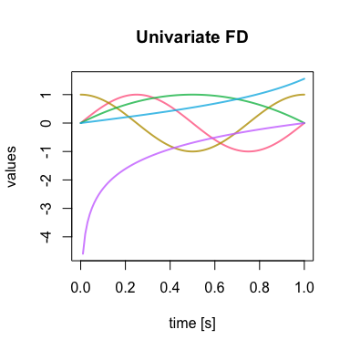

Figure 1: An example of a `fData` object, with 5 curves evaluated on a evenly spaced grid of 100 points.

An `mfData` object, instead, implements a multivariate functional dataset where each component is defined over the same indexing variable. In practice, we deal with a discrete grid $[t_0, t_1, \ldots, t_{P-1}]$ and a dataset of $N$ statistical units, each one having $L$ components observed over the same discrete grid: $D_{i,j,k} = X_{i,k}(t_{j})$, $\forall i = 1, \ldots, N$, $\forall j = 0, \ldots, P - 1$ and $\forall k = 1, \ldots, L$. The object `mfData` requires the evenly spaced grid of definition as parameter `grid` and a list containing the L components of the multivariate functional dataset, defined as 2D data structures (analogously to the constructor of `fData` class).  
The **S3** implementation allows to enrich the package with expressive operations that enable an easy manipulation of datasets, keeping at the same time a light structure that allow users to easily access the inner state of objects. For instance, we added an overloaded operator `` [``.fData `` (`` [``.mfData ``) that allows to use standard slices of `matrix` and `array` classes also for `fData` (`mfData`). We provided an overloaded implementation of the four basic algebraic operations, `+.fData`, `-.fData`, `*.fData`, `/.fData`, that allow to write and evaluate simple expressions on `fData` objects without explicitly carry them out on the set of measurements. `+.fData`, `-.fData` support the sum or subtraction of compatible functional datasets (e.g, same definition grid $I$ and same sample size $N$) or perform the element-wise (along the measurement direction, i.e., columns) sum or subtraction by a one-dimensional vector of compatible measurements (length $P$). The latter is useful, for instance, in order to translate or center data. The `*.fData`, `/.fData` operators perform an element-wise multiplication or division by a scalar quantity. We also added two convenience functions, `append_fData` and `append_mfData`, that can be used to concatenate two compatible (same definition grid $I$) functional datasets together.  
Statistics functions for the computation of the mean (specification of the generic `mean` function of R), the median (through `median_fData` and `median_mfData`, see Section 3 for more details), or the covariance (`cov fun` and its specifications for `fData` and `mfData`), are also implemented for `fData` and `mfData`.  
Finally, we implemented dedicated specialisations for the visualisation of functional data in `plot.fData` (`plot.mfData`). In case of `mfData` the graphical window is split into a rectangular lattice so that each component is plotted singularly. The rectangular frame has $\lfloor \sqrt L \rfloor$ rows and $\lceil \frac{L}{\lfloor \sqrt L \rfloor} \rceil$ columns. To give an example of this visualization method, consider the `mfD_healthy` dataset in the *roahd* package (see Figure 2).

```r
data("mfD_healthy", package = "roahd")
```

The dataset `mfD healthy` collects preprocessed (denoised, smoothed and registered) 8-leads electrocardiographic (ECG) signals during a median heartbeat of a sample of $50$ healthy subjects. An ECG signal records in a of voltage versus time the electrical activity of the heart using electrodes placed on the skin. These electrodes detect the small electrical changes that are a consequence of cardiac muscle depolarization followed by repolarization during each cardiac cycle (heartbeat). In a conventional 12-lead ECG, ten electrodes are placed on the patient’s limbs and on the surface of the chest. The overall magnitude of the heart’s electrical potential is then measured from twelve different angles (‘leads’). Of these 12 leads, the first six are derived from the same three measurement points. Therefore, any two of these six leads include exactly the same information as the other four. So, the ECG traces gathered of 8 leads, called I, II, V1, V2, V3, V4, V5 and V6. Analogously the dataset `mfD LBBB` contains the ECGs of $50$ patients affected by Left Bundle Branch Block, LBBB in the following. These data arise from the project PROMETEO (PROgetto sull’area Milanese Elettrocardiogrammi Teletrasferiti dall’Extra Ospedaliero) started with the aim of spreading the intensive use of ECG as pre-hospital diagnostic tool and of constructing a new database of ECGs with features never recorded before in any other data collection on heart diseases. Measures of electric potential are given in $\mu$V and the final sample grid after preprocessing consists of $1024$ points at $1$KHz. For more details on the original dataset, and on the preprocessing steps, see (F. Ieva et al. 2013).

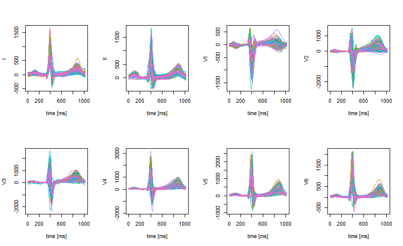

Figure 2: A visualization of the `mfD_healthy` dataset in the *roahd* package.